[figure not shown]

# Kobe Capstone Project

> OVERVIEW: Kobe Bryant marked his retirement from basketball by scoring 60 points in his final game as a member of the Los Angeles Laker team on Wednesday, April 12, 2016. Starting to play professional basketball at the age of 17, Kobe earned the sport’s highest accolades throughout his long career. Using 20 years of data on Kobe's shots made and shots missed, can you predict which shots will be successful?

## Objectives

1. Overall Objective: Build a predictive model to classify shots as missed or made, producing:
   - 1.1 **A logistic Regression Model**
   - 1.2 **A Linear Discrimination Analysis (LDA) model**
2. Build models to provide arguments and evidence for or against the propositions below. For Each Quanitfy your findings with statistical evidence *(Test, CI, plots, etc.)*
   - 2.1. The odds of Kobe making a shot decreases with respect to the distance he is from the hoop.
   - 2.2. The probability of Kobe making a shot decreases linearly with respects to the distacne he is from the hoop.
   - 2.3. The relationship between the distance Kobe is from te basket and the odds of him making the shot is different if they are in the playoffs.

```python
import pandas as pd
import numpy as np

# Statistical Packages
import scipy.stats as stats
import statsmodels.api as sm
import statsmodels.formula.api as smf

# import plotting libraries
from statsmodels.graphics.factorplots import interaction_plot
import matplotlib.pyplot as plt
import seaborn as sns
from scipy.stats import norm

# style
%matplotlib inline
plt.style.use('seaborn-white')

import warnings
warnings.filterwarnings('ignore')
pd.set_option('display.max_columns', 100, 'display.float_format', lambda x: '%.3f' % x)
#sns.set(style='white', context='notebook', palette='deep')
sns.set_style("darkgrid", {"axes.facecolor": ".9"})
sns.set_context("paper")

# https://seaborn.pydata.org/tutorial/color_palettes.html?highlight=color

# Seven hls color palette (right)
#current_palette_7 = sns.color_palette("hls", 7)
#sns.set_palette(current_palette_7)

# inverted colors: https://encycolorpedia.com/c0d74d
# lakers colors: https://teamcolorcodes.com/los-angeles-lakers-color-codes/
# inverted
# lakers_color = ["#c0d74d",  "#2550ff","#3498db", "#95a5a6", "#e74c3c", "#2ecc71"]
lakers_color = ["#552583", '#FDB927', "#000000", "#ffe4e1","#95a5a6", "#e74c3c"]
sns.set_palette(lakers_color)
```

```python
train = pd.read_csv("./data/modelData.csv")
test = pd.read_csv("./data/predData.csv")
train.head()
```

|  | recId | action_type | combined_shot_type | game_event_id | game_id | lat | loc_x | loc_y | lon | minutes_remaining | period | playoffs | season | seconds_remaining | shot_distance | shot_made_flag | shot_type | shot_zone_area | shot_zone_basic | shot_zone_range | team_id | team_name | game_date | matchup | opponent | shot_id | attendance | arena_temp | avgnoisedb |
| --- | --- | --- | --- | --- | --- | --- | --- | --- | --- | --- | --- | --- | --- | --- | --- | --- | --- | --- | --- | --- | --- | --- | --- | --- | --- | --- | --- | --- | --- |
| 0 | 1 | Jump Shot | Jump Shot | 12 | 20000012 | 34.044 | -157 | 0 | -118.427 | 10 | 1 | 0 | 2000-01 | 22 | 15 | 0 | 2PT Field Goal | Left Side(L) | Mid-Range | 8-16 ft. | 1610612747 | Los Angeles Lakers | 36830 | LAL @ POR | POR | 2 | 14707 | 69 | 94.060 |
| 1 | 4 | Driving Dunk Shot | Dunk | 155 | 20000012 | 34.044 | 0 | 0 | -118.270 | 6 | 2 | 0 | 2000-01 | 19 | 0 | 1 | 2PT Field Goal | Center(C) | Restricted Area | Less Than 8 ft. | 1610612747 | Los Angeles Lakers | 36830 | LAL @ POR | POR | 5 | 14707 | 69 | 94.060 |
| 2 | 5 | Jump Shot | Jump Shot | 244 | 20000012 | 34.055 | -145 | -11 | -118.415 | 9 | 3 | 0 | 2000-01 | 32 | 14 | 0 | 2PT Field Goal | Left Side(L) | Mid-Range | 8-16 ft. | 1610612747 | Los Angeles Lakers | 36830 | LAL @ POR | POR | 6 | 14707 | 69 | 94.060 |
| 3 | 6 | Layup Shot | Layup | 251 | 20000012 | 34.044 | 0 | 0 | -118.270 | 8 | 3 | 0 | 2000-01 | 52 | 0 | 1 | 2PT Field Goal | Center(C) | Restricted Area | Less Than 8 ft. | 1610612747 | Los Angeles Lakers | 36830 | LAL @ POR | POR | 7 | 14707 | 69 | 94.060 |
| 4 | 7 | Jump Shot | Jump Shot | 265 | 20000012 | 33.936 | -65 | 108 | -118.335 | 6 | 3 | 0 | 2000-01 | 12 | 12 | 1 | 2PT Field Goal | Left Side(L) | In The Paint (Non-RA) | 8-16 ft. | 1610612747 | Los Angeles Lakers | 36830 | LAL @ POR | POR | 9 | 14707 | 69 | 94.060 |

```python
print("Train data: ")
print("Training data Observations (rows): ", train.shape[0])
print("Training data Factors (columns): ", train.shape[1])
print("----------------------------------------------------")
print("Test data: ")
print("Test data Observations (rows): ", test.shape[0])
print("Test data Factors (columns): ", test.shape[1])
```

```
Train data:
Training data Observations (rows):  20697
Training data Factors (columns):  29
----------------------------------------------------
Test data:
Test data Observations (rows):  5000
Test data Factors (columns):  28
```

We can see from the above output that the train dataset has one additional column than the test dataset, which is appropriately due to the fact the train dataset has `shot_made_flag` which is the response variable tha is our objective to predict.

**Predict variable ($y$)** - did Kobe make the shot? (binary 1-make / 0-miss)

### Preliminary Summary Statistics and Data Analysis

```python
print("Kobe Preliminary Summary Statistics (training dataset)")
print("Number of career shots: ", len(train))
print("Average (Mean) Shot Made per Game: ", str("$"), round(train.groupby('game_id')['shot_made_flag'].mean().values.mean(),3))
print("Most Shots Made in a Game: ", train.groupby('game_id')['shot_made_flag'].sum().values.max())
print("Number of game made more than 15 shots: ", sum(train.groupby('game_id')['shot_made_flag'].sum().values > 15))
print("Number of game made less than 5 shots: ", sum(train.groupby('game_id')['shot_made_flag'].sum().values < 5))
print("Variability Shot Make (standard dev): ", round(train.groupby('game_id')['shot_made_flag'].sum().values.std(),3))
```

```
Kobe Preliminary Summary Statistics (training dataset)
Number of career shots:  20697
Average (Mean) Shot Made per Game:  $ 0.446
Most Shots Made in a Game:  18
Number of game made more than 15 shots:  6
Number of game made less than 5 shots:  523
Variability Shot Make (standard dev):  3.02
```

```python
train.info()
```

```
<class 'pandas.core.frame.DataFrame'>
RangeIndex: 20697 entries, 0 to 20696
Data columns (total 29 columns):
recId                 20697 non-null int64
action_type           20697 non-null object
combined_shot_type    20697 non-null object
game_event_id         20697 non-null int64
game_id               20697 non-null int64
lat                   20697 non-null float64
loc_x                 20697 non-null int64
loc_y                 20697 non-null int64
lon                   20697 non-null float64
minutes_remaining     20697 non-null int64
period                20697 non-null int64
playoffs              20697 non-null int64
season                20697 non-null object
seconds_remaining     20697 non-null int64
shot_distance         20697 non-null int64
shot_made_flag        20697 non-null int64
shot_type             20697 non-null object
shot_zone_area        20697 non-null object
shot_zone_basic       20697 non-null object
shot_zone_range       20697 non-null object
team_id               20697 non-null int64
team_name             20697 non-null object
game_date             20697 non-null int64
matchup               20697 non-null object
opponent              20697 non-null object
shot_id               20697 non-null int64
attendance            20697 non-null int64
arena_temp            20697 non-null int64
avgnoisedb            20697 non-null float64
dtypes: float64(3), int64(16), object(10)
memory usage: 4.6+ MB
```

**Data Quality Check** lets check the columsn that contain `NaN` values.

```python
train.columns[train.isnull().any()].tolist()
```

```
[]
```

combine data sets for EDA

```python
kobe = pd.concat((train, test), axis = 0, ignore_index=True)
#kobe = pd.read_csv("./data/data.csv")
print("Combined data: ")
print("Combined data Observations (rows): ", kobe.shape[0])
print("Combined data Factors (columns): ", kobe.shape[1])
```

```
Combined data:
Combined data Observations (rows):  25697
Combined data Factors (columns):  29
```

## Exploratory Data Analysis

To get started with exploratory analysis, we set out to first review Kobe's distribution of shots made vs shots missed.

```
shot_made_flag
0.000    11431
1.000     9266
dtype: int64
```

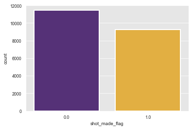

```python
sns.countplot('shot_made_flag',  data=kobe, linewidth=2) #hue='shot_type',
print(kobe.groupby('shot_made_flag').size())
#print(kobe.groupby(['shot_type','shot_made_flag']).size())
```

Next let see the distirbution of kobe's `shot zone` (where kobe shot the ball on the court) and the number of time he made or missed the shot.

```
['Mid-Range' 'Restricted Area' 'In The Paint (Non-RA)' 'Above the Break 3'
 'Backcourt' 'Right Corner 3' 'Left Corner 3']
```

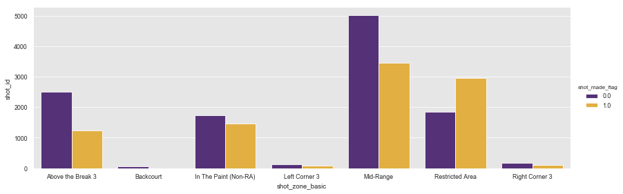

```python
print(kobe.shot_zone_basic.unique())
sns.catplot(x='shot_zone_basic', y='shot_id',
            hue='shot_made_flag', kind='bar', height=4, aspect=11.7/4,
           data=kobe.groupby(['shot_zone_basic','shot_made_flag'])['shot_id'].count().reset_index())
```

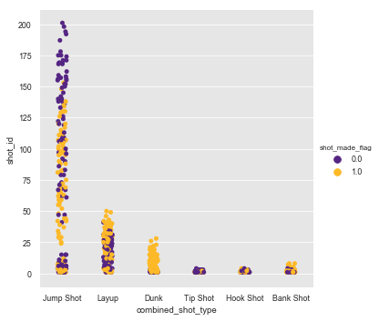

```python
sns.catplot(x='combined_shot_type', y='shot_id', hue='shot_made_flag', data=kobe.groupby(['season','period','combined_shot_type','shot_made_flag'])['shot_id'].count().reset_index())
```

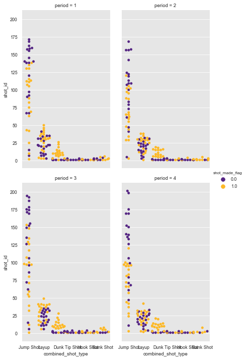

```python
sns.catplot(x="combined_shot_type", y="shot_id", hue="shot_made_flag",
            col="period", aspect=.6,
            kind="swarm",  col_wrap=2,
            data=kobe[kobe.period <=4].groupby(['season',
                                                'period','combined_shot_type','shot_made_flag'])['shot_id'].count().reset_index())
```

```
No handles with labels found to put in legend.
```

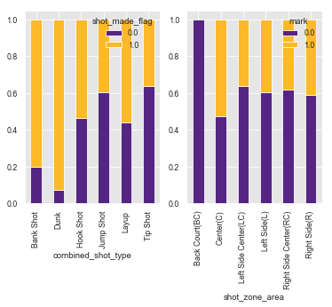

```python
fig, axes3 = plt.subplots(1,2)
table = pd.crosstab(kobe.combined_shot_type, kobe.shot_made_flag)

# https://stackoverflow.com/questions/51977217/getting-empty-plots-when-using-subplots-in-matplotlib
ax = table.div(table.sum(1).astype(float), axis=0).plot(kind='bar', stacked=True, ax=axes3[0])
plt.legend(title='mark', loc=8)

table = pd.crosstab(kobe.shot_zone_area, kobe.shot_made_flag)
table.div(table.sum(1).astype(float), axis=0).plot(kind='bar', stacked=True, ax=axes3[1])
plt.legend(title='mark', loc=0)
plt.show()
```

It appears that `combined_shot_type` can be in the consideration of a predictor variable, especially `Dunks`, `Bank Shots`, which are Kobe's bread and butter.

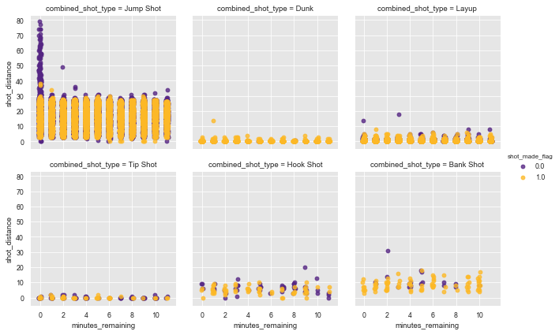

```python
# https://seaborn.pydata.org/tutorial/axis_grids.html
g = sns.FacetGrid(kobe, col="combined_shot_type", hue="shot_made_flag",
                  col_wrap=3, margin_titles=True)
g.map(sns.regplot, "minutes_remaining",  "shot_distance",
      fit_reg=False, x_jitter=.1)
g.add_legend();
```

The above graph appears that when reviewing the different combinaitons of Kobe's shot type, Kobe's `bread and butter` are contnued to indicate predictor variables for Kobe's made shots for the exeption of `combined_shot_type = Jump Shot` where kobe is pretty consistent in respects to distance, when there is more than 1 min remain in the quarter.

**Kobe's Shot Zone Area**

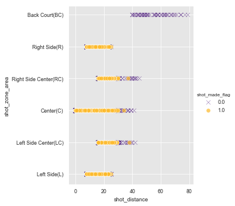

```python
g = sns.FacetGrid(kobe, hue="shot_made_flag", height=5,aspect=1, hue_kws={"marker": ["x", "o"]})
g.map(plt.scatter, "shot_distance", "shot_zone_area", s=50, alpha=.7, linewidth=.5, edgecolor="white")
g.add_legend();
```

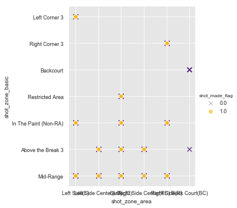

```python
g = sns.FacetGrid(kobe, hue="shot_made_flag", height=5,aspect=1, hue_kws={"marker": ["x", "o"]})
g.map(plt.scatter, "shot_zone_area", "shot_zone_basic", s=50, alpha=.7, linewidth=.5, edgecolor="white")
g.add_legend();
```

Gaining an understanding of Kobe's shot placement on the floor, obviosly, `Back Court (BC)` can be said to be a great predictor for when kobe misses the shot, seemingly enough, it appears Kobe shoot consitantly better in roughly the same range location as his shot moves further away from the center of the court, indicated by the `Right Side (R)` and `Left Side (L)` variables. these will make for good dummy variables, which we will create as `kobe_shot_loc` as:

```python
kobe.loc[(kobe.shot_zone_area!='Back Court(BC)') & (kobe.shot_distance<30), 'kobe_shot_loc'] = 1
kobe.loc[(kobe.kobe_shot_loc!=1), 'kobe_shot_loc'] = 0
```

## Feature Engineering

```python
kobe = kobe.sort_values(by=["game_id","shot_id"], ascending=True)

# prior shot made
kobe['prior_shot_made'] =(kobe.groupby(['game_id'])['shot_made_flag'].shift(1))

# set the first shot to each game as zero to reset the cum shot score
kobe.loc[kobe.groupby('game_id').shot_id.idxmin(), "prior_shot_made"] = 0

# include prior shot made from last record of shot from that game
kobe['prior_shot_made'] = (kobe.groupby("game_id")['prior_shot_made'].transform(lambda x: x.ffill().bfill()))
```

```python
# cumsum made shots
kobe['cum_shot_made'] = kobe.shot_made_flag

# set the cumshot for shots to be predicted as zero which will be a placeholder and
# include current shooting streak to up to this point in the game
kobe.loc[kobe.shot_made_flag.isnull(), 'cum_shot_made'] = 0


# set the first shot to each game as zero to reset the cum shot score
kobe.loc[kobe.groupby('game_id').shot_id.idxmin(), "cum_shot_made"] = 0

#kobe['cum_shot_made'] = (kobe.groupby(['game_id'])['cum_shot_made'].eq(0).cumsum())
kobe['cum_shot_made'] = (kobe.groupby(kobe.cum_shot_made.eq(0).cumsum()).cumcount())
kobe.loc[kobe.shot_made_flag.isnull(), 'cum_shot_made'] = np.nan
kobe['cum_shot_made'] = (kobe.groupby(['game_id'])['cum_shot_made'].transform(lambda x: x.ffill().bfill()))
```

```python
# null values
kobe.loc[kobe.cum_shot_made.isnull(),'cum_shot_made'] = 1 # all are less than 20 ft
```

Next we will create a unique identifier for each team with an `Opp` suffix.

```python
kobe['opp'] = kobe.matchup.apply(lambda x: x[-3:])
kobe['oppSeason'] = kobe.matchup.apply(lambda x: x[-3:])+kobe.season
```

Create variable for home game

```python
kobe['home_game'] = kobe.matchup.apply(lambda x: 0 if "@" in x else 1)
```

Create a hothand function to group kobe shots based on the number consecutive shots

```python
def hothand(y):
    if y  > 4:
        return 'fire' # use to be 'fire'
    elif y == 3:
        return 'hot hand'
    elif y > 0:
        return 'heat'
    elif y == 0:
        return 'nil'
    elif y < 0:
        return 'cold'
kobe['hot_hand'] = [hothand(k) for k in kobe.cum_shot_made.values]
```

```python
kobe['hot_hand'] = (kobe.groupby("game_id")['hot_hand'].transform(lambda x: x.bfill().ffill()))
```

Lets see the distribution of the hothand function on Kobe.

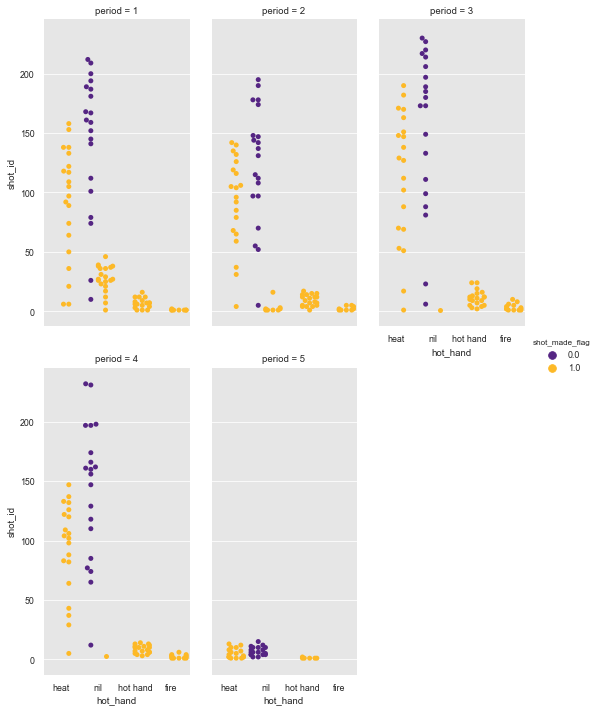

```python
g= sns.catplot(x="hot_hand", y="shot_id", hue="shot_made_flag",
            col="period", aspect=.5,
            kind="swarm", col_wrap=3, dodge=True,
            data=kobe[kobe.period <=5].groupby(['season','period','hot_hand','shot_made_flag'])['shot_id'].count().reset_index())
```

Lets create a feature to keep track of Kobe's current points. Perhaps the more points Kobe has the higher likelihood we can predict whether his next shot will go in.

2 Pts and 3Pts now we convert each make and miss to a score and then we cumulatively sum it for a running average.

```python
kobe.loc[(kobe['shot_made_flag']==1) & (kobe['shot_type']=='2PT Field Goal'),'pts'] = 2
kobe.loc[(kobe['shot_made_flag']==1) & (kobe['shot_type']=='3PT Field Goal'),'pts'] = 3
kobe.loc[(kobe['shot_made_flag']==0) | (kobe.shot_made_flag.isnull()) ,'pts'] = 0
kobe['pts'] = (kobe.groupby(['game_id'])['pts'].cumsum())
```

Next lets create a field goal percentage

Formula Field goal percentage (FG%) calculates as:

[figure not shown]

```python
# 2 Pointers
kobe.loc[(kobe['shot_type']=='2PT Field Goal'),'field_goal_attempts'] = 1
kobe.loc[(kobe['shot_type']=='3PT Field Goal'),'field_goal_attempts'] = 0
kobe.loc[(kobe['shot_type']=='3PT Field Goal'),'field_goal'] = 0
kobe.loc[(kobe['shot_made_flag']==1) & (kobe['shot_type']=='2PT Field Goal'),'field_goal'] = 1
kobe.loc[(kobe['shot_made_flag']==0) & (kobe['shot_type']=='2PT Field Goal'),'field_goal'] = 0


# make no assuption on test data
kobe.loc[kobe.shot_made_flag.isnull(),'field_goal_attempts'] = 0
kobe.loc[kobe.shot_made_flag.isnull(),'field_goal'] = 0

# sort data frame
kobe = kobe.sort_values(by=["game_id","shot_id"], ascending=True)
# set the first shot to each game as zero to reset the cum shot score
kobe.loc[kobe.groupby('game_id').shot_id.idxmin(), "three_pt_attempts"] = 0
kobe.loc[kobe.groupby('game_id').shot_id.idxmin(), "three_pt"] = 0

#cumsum
kobe['field_goal_attempts'] = (kobe.groupby(['game_id'])['field_goal_attempts'].cumsum())
kobe['field_goal'] = (kobe.groupby(['game_id'])['field_goal'].cumsum())
kobe['fg_pct'] = kobe.field_goal / kobe.field_goal_attempts
kobe.loc[(kobe['fg_pct'].isnull()) | (kobe.fg_pct == np.inf),'fg_pct'] = 0

# 3 Pointers
kobe.loc[(kobe['shot_type']=='3PT Field Goal'), 'three_pt_attempts'] = 1
kobe.loc[(kobe['shot_type']=='2PT Field Goal'),'three_pt_attempts'] = 0
kobe.loc[(kobe['shot_made_flag']==1) & (kobe['shot_type']=='3PT Field Goal'),'three_pt'] = 1
kobe.loc[(kobe['shot_made_flag']==0) & (kobe['shot_type']=='3PT Field Goal'),'three_pt'] = 0

# make no assuption on test data
kobe.loc[kobe.shot_made_flag.isnull(),'three_pt_attempts'] = 0
kobe.loc[kobe.shot_made_flag.isnull(),'three_pt'] = 0


kobe['three_pt_attempts'] = (kobe.groupby(['game_id'])['three_pt_attempts'].cumsum())
kobe['three_pt'] = (kobe.groupby(['game_id'])['three_pt'].cumsum())
kobe['three_pt'] = (kobe.groupby(['game_id'])['three_pt'].transform(lambda x: x.ffill().bfill()))
kobe['three_pct'] = kobe.three_pt / kobe.three_pt_attempts
kobe.loc[(kobe['three_pct'].isnull()) | (kobe.three_pct == np.inf),'three_pct'] = 0
```

```python
kobe[['game_id', 'shot_id', 'shot_made_flag', 'shot_type',
     'field_goal_attempts',
     'field_goal','fg_pct', "three_pt_attempts", "three_pt", "three_pct"]].head()

#'cum_shot_made', 'prior_shot_made', 'hot_hand', 'pts',
```

|  | game_id | shot_id | shot_made_flag | shot_type | field_goal_attempts | field_goal | fg_pct | three_pt_attempts | three_pt | three_pct |
| --- | --- | --- | --- | --- | --- | --- | --- | --- | --- | --- |
| 0 | 20000012 | 2 | 0.000 | 2PT Field Goal | 1.000 | 0.000 | 0.000 | 0.000 | 0.000 | 0.000 |
| 20697 | 20000012 | 3 | nan | 2PT Field Goal | 1.000 | 0.000 | 0.000 | 0.000 | 0.000 | 0.000 |
| 20698 | 20000012 | 4 | nan | 2PT Field Goal | 1.000 | 0.000 | 0.000 | 0.000 | 0.000 | 0.000 |
| 1 | 20000012 | 5 | 1.000 | 2PT Field Goal | 2.000 | 1.000 | 0.500 | 0.000 | 0.000 | 0.000 |
| 2 | 20000012 | 6 | 0.000 | 2PT Field Goal | 3.000 | 1.000 | 0.333 | 0.000 | 0.000 | 0.000 |

```python
# save file
kobe[['game_id', 'shot_id', 'shot_made_flag', 'shot_type',
     'cum_shot_made', 'prior_shot_made', 'hot_hand', 'pts', 'field_goal_attempts',
     'field_goal','fg_pct', "three_pt_attempts", "three_pt", "three_pct"]].to_csv("./data/kobe_dat.csv")
#kobe.to_csv("./data/kobe_data_kaggle.csv")
```

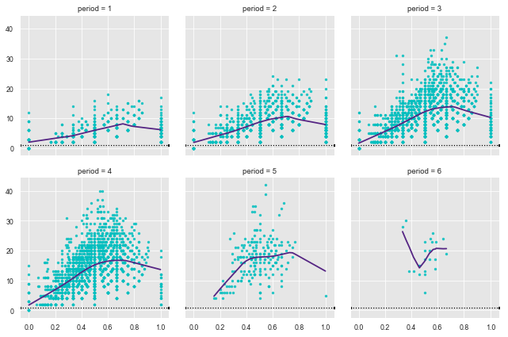

```python
g = sns.lmplot('fg_pct', 'pts', col='period', data=kobe[kobe.period <=6].groupby(['season','period','pts','fg_pct'])['shot_id'].count().reset_index(),
               markers=".", scatter_kws=dict(color='c'),
              col_wrap=3, height=3, lowess=True)
g.map(plt.axhline, y=1, color="k", ls=":");
```

##### Encodings

We will start by iniializing 3 label encoders, below are the labels and the current unique categories.

- shot_zone_range: '8-16 ft.', '16-24 ft.', 'Less Than 8 ft.', '24+ ft.','Back Court Shot'
- shot_type : '2PT Field Goal', '3PT Field Goal'
- shot_zone_basic: 'Mid-Range', 'Restricted Area', 'In The Paint (Non-RA)','Above the Break 3', 'Right Corner 3', 'Backcourt', 'Left Corner 3'

```python
from sklearn.preprocessing import LabelEncoder

le_shot_zone_range = LabelEncoder()
le_shot_type = LabelEncoder()
le_shot_zone_basic = LabelEncoder()

kobe['range_encoded'] = le_shot_zone_range.fit_transform(kobe.shot_zone_range)
kobe['type_encoded'] = le_shot_type.fit_transform(kobe.shot_type)
kobe['basic_encoded'] = le_shot_zone_basic.fit_transform(kobe.shot_zone_basic)
```

#### Data From Another Source

Atfer a quick search, found [bakcsetball-reference.com](https://www.basketball-reference.com/players/b/bryanko01.html) that we used their:

- Game won / loss

to assist with addtional information for a better preditive model. creating another variable to indicate whether Lakers won the game or not

```python
wl = pd.read_csv("./data/kobe_win_loss.csv")
#wl = pd.read_csv("./data/kobe_win_loss_kaggle.csv")
kobe = pd.merge(kobe, wl, on="game_date", how="left")
```

add career rating stats I had to add 500 rating when kobe was not rated https://stats.nba.com/player/977/career/

```python
rating = pd.read_csv("./data/career_ratings.csv")
kobe = pd.merge(kobe, rating, on="season", how='left')
```

```python
kobe['top_rated'] = kobe.PTS_rating.apply(lambda x: 1 if x<20 else 0)
```

dummy variables

```python
kobe = pd.concat([kobe, pd.get_dummies(kobe[['hot_hand']])], axis=1)
```

```python
kobe.to_csv("./data/kobe_dat.csv")
```

```python
kobe.columns[kobe.isnull().any()].tolist()
```

```
['shot_made_flag']
```

### Correlation Analysis

```python
# df_train comes form the 'flag = train' flag in the dataset.
train_corr = kobe[~kobe.shot_made_flag.isnull()].corr()
#kobe_corr['shot_made_flag'].sort_values(ascending=False)

train_correlation_target = abs(train_corr.shot_made_flag)
corr_matrix = train_correlation_target[train_correlation_target>0.05]
potentialFeatures=list(corr_matrix)
```

```python
# create a function for plotting a dataframe with string columns and numeric values

def plot_dataframe(df, y_label):
    color='coral'
    fig = plt.gcf()
    fig.set_size_inches(20,12)
    plt.ylabel(y_label)

    ax = df.correlation.plot(linewidth=3.3, color=color)
    ax.set_xticks(df.index)
    ax.set_xticklabels(df.attributes, rotation=75); #Notice the ; (remove it and see what happens !)
    plt.show()
```

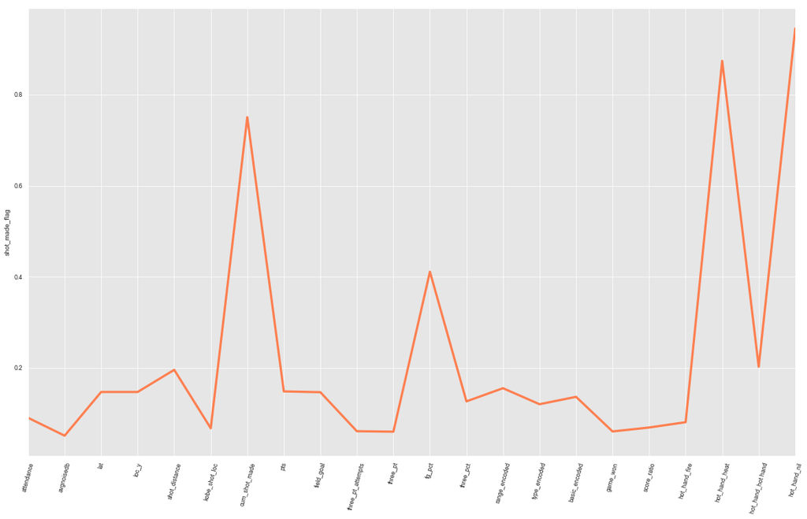

|  | attributes | correlation |
| --- | --- | --- |
| 21 | hot_hand_nil | 0.945 |
| 19 | hot_hand_heat | 0.874 |
| 6 | cum_shot_made | 0.751 |
| 11 | fg_pct | 0.411 |
| 20 | hot_hand_hot hand | 0.203 |
| 4 | shot_distance | 0.196 |
| 13 | range_encoded | 0.155 |
| 7 | pts | 0.148 |
| 3 | loc_y | 0.147 |
| 2 | lat | 0.147 |
| 8 | field_goal | 0.147 |
| 15 | basic_encoded | 0.136 |
| 12 | three_pct | 0.127 |
| 14 | type_encoded | 0.120 |
| 0 | attendance | 0.090 |
| 18 | hot_hand_fire | 0.081 |
| 17 | score_ratio | 0.069 |
| 5 | kobe_shot_loc | 0.067 |
| 9 | three_pt_attempts | 0.061 |
| 16 | game_won | 0.060 |
| 10 | three_pt | 0.060 |
| 1 | avgnoisedb | 0.051 |

```python
# create a dataframe suing cols and correlations
corr_matrix_ = corr_matrix[~corr_matrix.index.isin(['shot_made_flag'])]

df5 = pd.DataFrame({'attributes': corr_matrix_.index, 'correlation': corr_matrix_.values})

# lets plot above dataframe using the function we created

plot_dataframe(df5, 'shot_made_flag')
df5.sort_values('correlation',ascending=False)
```

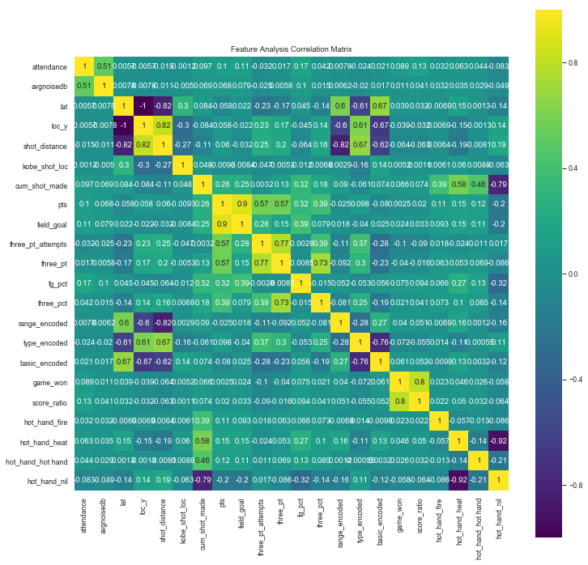

```python
corr_matrix = kobe[~kobe.shot_made_flag.isnull()][list(corr_matrix_.index)].corr()

plt.figure(figsize=(12,12))
ax= plt.axes()
sns.heatmap(corr_matrix, vmax=1, square=True, annot=True, cmap='viridis', ax=ax)
ax.set_title('Feature Analysis Correlation Matrix')
plt.show()
```

#### Multicoliniarity

VIF

```python
#https://etav.github.io/python/vif_factor_python.html
from statsmodels.stats.outliers_influence import variance_inflation_factor
# For each X, calculate VIF and save in dataframe
vif = pd.DataFrame()
vif["VIF Factor"] = [variance_inflation_factor(corr_matrix.values, i) for i in range(corr_matrix.shape[1])]
vif["features"] = corr_matrix.columns
print("Variance Inflation Factor for Heatmap Predictors")
vif.round(1)
```

```
Variance Inflation Factor for Heatmap Predictors
```

|  | VIF Factor | features |
| --- | --- | --- |
| 0 | 2.900 | attendance |
| 1 | 2.700 | avgnoisedb |
| 2 | 57506914.400 | lat |
| 3 | 44127244.200 | loc_y |
| 4 | 2313.900 | shot_distance |
| 5 | 22.300 | kobe_shot_loc |
| 6 | 260.300 | cum_shot_made |
| 7 | 15427891.800 | pts |
| 8 | 62931249.800 | field_goal |
| 9 | 79.800 | three_pt_attempts |
| 10 | 3200581.300 | three_pt |
| 11 | 3.000 | fg_pct |
| 12 | 43.400 | three_pct |
| 13 | 682.300 | range_encoded |
| 14 | 204.700 | type_encoded |
| 15 | 66.800 | basic_encoded |
| 16 | 19.100 | game_won |
| 17 | 19.200 | score_ratio |
| 18 | 92696304.700 | hot_hand_fire |
| 19 | 14196175.400 | hot_hand_heat |
| 20 | 274770541.200 | hot_hand_hot hand |
| 21 | 55259035.600 | hot_hand_nil |

```python
corr_matrix
```

|  | attendance | avgnoisedb | lat | loc_y | shot_distance | kobe_shot_loc | cum_shot_made | pts | field_goal | three_pt_attempts | three_pt | fg_pct | three_pct | range_encoded | type_encoded | basic_encoded | game_won | score_ratio | hot_hand_fire | hot_hand_heat | hot_hand_hot hand | hot_hand_nil |
| --- | --- | --- | --- | --- | --- | --- | --- | --- | --- | --- | --- | --- | --- | --- | --- | --- | --- | --- | --- | --- | --- | --- |
| attendance | 1.000 | 0.513 | 0.006 | -0.006 | -0.015 | -0.001 | 0.097 | 0.102 | 0.113 | -0.032 | 0.017 | 0.171 | 0.042 | 0.008 | -0.024 | 0.021 | 0.089 | 0.128 | 0.032 | 0.063 | 0.044 | -0.083 |
| avgnoisedb | 0.513 | 1.000 | 0.008 | -0.008 | -0.011 | -0.005 | 0.069 | 0.068 | 0.079 | -0.025 | 0.006 | 0.100 | 0.015 | 0.006 | -0.020 | 0.017 | 0.011 | 0.041 | 0.032 | 0.035 | 0.029 | -0.049 |
| lat | 0.006 | 0.008 | 1.000 | -1.000 | -0.818 | 0.304 | 0.084 | -0.058 | 0.022 | -0.226 | -0.173 | 0.045 | -0.142 | 0.599 | -0.606 | 0.674 | 0.039 | 0.032 | -0.007 | 0.146 | 0.001 | -0.143 |
| loc_y | -0.006 | -0.008 | -1.000 | 1.000 | 0.818 | -0.304 | -0.084 | 0.058 | -0.022 | 0.226 | 0.173 | -0.045 | 0.142 | -0.599 | 0.606 | -0.674 | -0.039 | -0.032 | 0.007 | -0.146 | -0.001 | 0.143 |
| shot_distance | -0.015 | -0.011 | -0.818 | 0.818 | 1.000 | -0.265 | -0.114 | 0.060 | -0.032 | 0.249 | 0.196 | -0.064 | 0.164 | -0.825 | 0.667 | -0.618 | -0.064 | -0.063 | 0.006 | -0.190 | -0.008 | 0.189 |
| kobe_shot_loc | -0.001 | -0.005 | 0.304 | -0.304 | -0.265 | 1.000 | 0.048 | -0.009 | -0.008 | -0.047 | -0.005 | -0.012 | 0.007 | 0.003 | -0.163 | 0.135 | 0.005 | 0.001 | 0.006 | 0.060 | 0.009 | -0.063 |
| cum_shot_made | 0.097 | 0.069 | 0.084 | -0.084 | -0.114 | 0.048 | 1.000 | 0.263 | 0.249 | 0.003 | 0.127 | 0.323 | 0.181 | 0.090 | -0.061 | 0.074 | 0.066 | 0.074 | 0.390 | 0.581 | 0.460 | -0.794 |
| pts | 0.102 | 0.068 | -0.058 | 0.058 | 0.060 | -0.009 | 0.263 | 1.000 | 0.900 | 0.571 | 0.570 | 0.318 | 0.387 | -0.025 | 0.098 | -0.080 | 0.003 | 0.020 | 0.105 | 0.147 | 0.123 | -0.205 |
| field_goal | 0.113 | 0.079 | 0.022 | -0.022 | -0.032 | -0.008 | 0.249 | 0.900 | 1.000 | 0.278 | 0.155 | 0.387 | 0.079 | 0.018 | -0.040 | 0.025 | 0.024 | 0.033 | 0.093 | 0.149 | 0.112 | -0.200 |
| three_pt_attempts | -0.032 | -0.025 | -0.226 | 0.226 | 0.249 | -0.047 | 0.003 | 0.571 | 0.278 | 1.000 | 0.771 | -0.003 | 0.386 | -0.107 | 0.373 | -0.285 | -0.100 | -0.090 | 0.018 | -0.024 | 0.011 | 0.017 |
| three_pt | 0.017 | 0.006 | -0.173 | 0.173 | 0.196 | -0.005 | 0.127 | 0.570 | 0.155 | 0.771 | 1.000 | -0.008 | 0.728 | -0.092 | 0.298 | -0.227 | -0.040 | -0.016 | 0.063 | 0.053 | 0.069 | -0.086 |
| fg_pct | 0.171 | 0.100 | 0.045 | -0.045 | -0.064 | -0.012 | 0.323 | 0.318 | 0.387 | -0.003 | -0.008 | 1.000 | -0.015 | 0.052 | -0.053 | 0.056 | 0.075 | 0.094 | 0.066 | 0.272 | 0.131 | -0.324 |
| three_pct | 0.042 | 0.015 | -0.142 | 0.142 | 0.164 | 0.007 | 0.181 | 0.387 | 0.079 | 0.386 | 0.728 | -0.015 | 1.000 | -0.081 | 0.253 | -0.186 | 0.021 | 0.041 | 0.073 | 0.105 | 0.085 | -0.144 |
| range_encoded | 0.008 | 0.006 | 0.599 | -0.599 | -0.825 | 0.003 | 0.090 | -0.025 | 0.018 | -0.107 | -0.092 | 0.052 | -0.081 | 1.000 | -0.280 | 0.270 | 0.040 | 0.051 | -0.007 | 0.158 | 0.001 | -0.155 |
| type_encoded | -0.024 | -0.020 | -0.606 | 0.606 | 0.667 | -0.163 | -0.061 | 0.098 | -0.040 | 0.373 | 0.298 | -0.053 | 0.253 | -0.280 | 1.000 | -0.758 | -0.072 | -0.055 | 0.014 | -0.111 | -0.001 | 0.107 |
| basic_encoded | 0.021 | 0.017 | 0.674 | -0.674 | -0.618 | 0.135 | 0.074 | -0.080 | 0.025 | -0.285 | -0.227 | 0.056 | -0.186 | 0.270 | -0.758 | 1.000 | 0.061 | 0.052 | -0.010 | 0.127 | 0.003 | -0.124 |
| game_won | 0.089 | 0.011 | 0.039 | -0.039 | -0.064 | 0.005 | 0.066 | 0.003 | 0.024 | -0.100 | -0.040 | 0.075 | 0.021 | 0.040 | -0.072 | 0.061 | 1.000 | 0.798 | 0.023 | 0.046 | 0.026 | -0.058 |
| score_ratio | 0.128 | 0.041 | 0.032 | -0.032 | -0.063 | 0.001 | 0.074 | 0.020 | 0.033 | -0.090 | -0.016 | 0.094 | 0.041 | 0.051 | -0.055 | 0.052 | 0.798 | 1.000 | 0.022 | 0.050 | 0.032 | -0.064 |
| hot_hand_fire | 0.032 | 0.032 | -0.007 | 0.007 | 0.006 | 0.006 | 0.390 | 0.105 | 0.093 | 0.018 | 0.063 | 0.066 | 0.073 | -0.007 | 0.014 | -0.010 | 0.023 | 0.022 | 1.000 | -0.057 | -0.013 | -0.086 |
| hot_hand_heat | 0.063 | 0.035 | 0.146 | -0.146 | -0.190 | 0.060 | 0.581 | 0.147 | 0.149 | -0.024 | 0.053 | 0.272 | 0.105 | 0.158 | -0.111 | 0.127 | 0.046 | 0.050 | -0.057 | 1.000 | -0.144 | -0.925 |
| hot_hand_hot hand | 0.044 | 0.029 | 0.001 | -0.001 | -0.008 | 0.009 | 0.460 | 0.123 | 0.112 | 0.011 | 0.069 | 0.131 | 0.085 | 0.001 | -0.001 | 0.003 | 0.026 | 0.032 | -0.013 | -0.144 | 1.000 | -0.214 |
| hot_hand_nil | -0.083 | -0.049 | -0.143 | 0.143 | 0.189 | -0.063 | -0.794 | -0.205 | -0.200 | 0.017 | -0.086 | -0.324 | -0.144 | -0.155 | 0.107 | -0.124 | -0.058 | -0.064 | -0.086 | -0.925 | -0.214 | 1.000 |

```python
potentialFeatures = [
 'shot_distance', 'game_won','score_ratio',
 'pts','kobe_shot_loc',
 'field_goal','hot_hand_heat',
 'fg_pct','attendance',
 'three_pct',
 'top_rated']
```

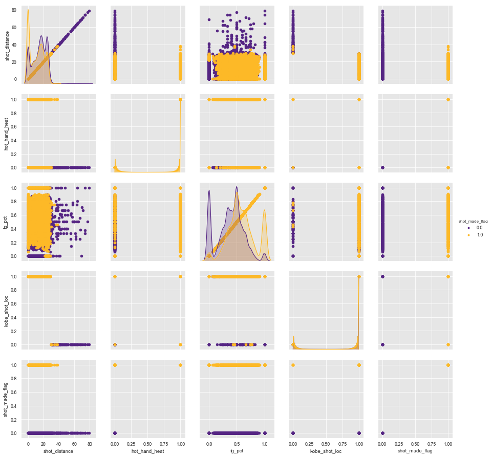

```python
g = sns.pairplot(kobe[['shot_distance','hot_hand_heat','fg_pct','kobe_shot_loc',
                       'shot_made_flag']], hue='shot_made_flag',
                diag_kind="kde", height=2.5, )
g.map(plt.scatter);
```

Create a graph to plot top features to show importance

```python
def plot_feature_importances_playoffs(model):
    plt.figure(figsize=(10,5))
    importance = model.feature_importances_
    importance = -np.sort(-importance)
    n_features = len(importance[:20])
    plt.barh(range(n_features), importance[:20], align='center')
    plt.yticks(np.arange(n_features), X)
    plt.xlabel("Feature importance")
    plt.ylabel("Feature")
    plt.ylim(-1, n_features)
```

## Modeling

Great!! Now lets get to modeling!

```python
# y includes our labels (wins and losses) and x includes our features
y = kobe[~kobe.shot_made_flag.isnull()].shot_made_flag
X = kobe[~kobe.shot_made_flag.isnull()][potentialFeatures]

# test train split
from sklearn.model_selection import train_test_split

# split data train 70% and test 30%
X_train, X_test, y_train, y_test = train_test_split(X, y, test_size = 0.3, random_state = 42)
```

### Logistic Regression Model

```
LogLoss  1.96
Accuracy on training set: 0.943
Accuracy on test set: 0.941
Feature Importance:
 None

Classification Report
              precision    recall  f1-score   support

         0.0       0.90      1.00      0.95      3381
         1.0       1.00      0.87      0.93      2829

   micro avg       0.94      0.94      0.94      6210
   macro avg       0.95      0.94      0.94      6210
weighted avg       0.95      0.94      0.94      6210
```

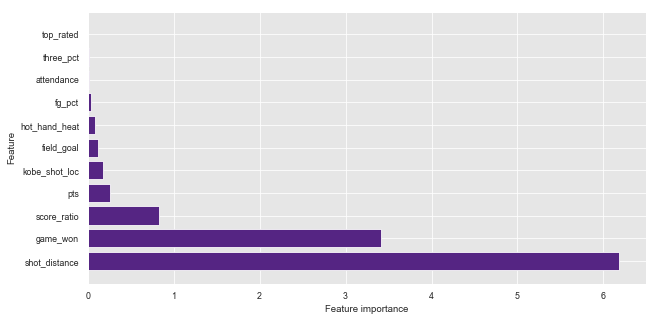

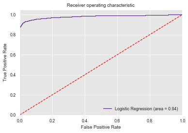

```python
from sklearn.linear_model import LogisticRegression
from sklearn.metrics import accuracy_score
from sklearn import metrics
from sklearn.metrics import classification_report

logreg = LogisticRegression()
logreg.fit(X_train, y_train)

Y_pred = logreg.predict(X_test)

print("LogLoss ", round(metrics.log_loss(y_train,logreg.predict(X_train)),3))
print("Accuracy on training set: {:.3f}".format(accuracy_score(y_train,logreg.predict(X_train))))
print("Accuracy on test set: {:.3f}".format(accuracy_score(y_test,logreg.predict(X_test))))

# create object for feature importance map
# https://stackoverflow.com/questions/51462979/how-to-get-feature-importance-in-logistic-regression-using-weights
weights = logreg.coef_
abs_weights = np.abs(weights)
logreg.feature_importances_ = abs_weights[0]
print("Feature Importance: \n",plot_feature_importances_playoffs(logreg))
print("\nClassification Report")
print(classification_report(y_test, logreg.predict(X_test)))


from sklearn.metrics import roc_auc_score
from sklearn.metrics import roc_curve

rf_roc_auc = roc_auc_score(y_test, logreg.predict(X_test))
rf_fpr, rf_tpr, rf_thresholds = roc_curve(y_test, logreg.predict_proba(X_test)[:,1])

plt.figure()
#plt.plot(fpr, tpr, label='GradientBoosting (area = %0.2f)' % gb_roc_auc)
plt.plot(rf_fpr, rf_tpr, label='Logistic Regression (area = %0.2f)' % rf_roc_auc)
plt.plot([0, 1], [0, 1],'r--')
plt.xlim([0.0, 1.0])
plt.ylim([0.0, 1.05])
plt.xlabel('False Positive Rate')
plt.ylabel('True Positive Rate')
plt.title('Receiver operating characteristic')
plt.legend(loc="lower right")
#plt.savefig('ROC')
plt.show()
```

**Linear Discriminate Analysis:**

```python
# https://blog.eduonix.com/artificial-intelligence/linear-discriminant-analysis-with-scikit-learn/

# load up preprocessing
from sklearn.preprocessing import StandardScaler
sc = StandardScaler()
kobe_features = sc.fit_transform(X)
```

```
Accuracy of LDA classifier on training set: 0.94
Accuracy of LDA classifier on test set: 0.93
Feature Importance:
 None
```

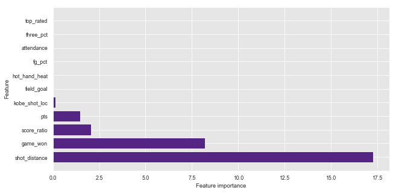

```python
from sklearn.discriminant_analysis import LinearDiscriminantAnalysis
lda = LinearDiscriminantAnalysis()
lda.fit(X_train, y_train)
print('Accuracy of LDA classifier on training set: {:.2f}'.format(lda.score(X_train, y_train)))
print('Accuracy of LDA classifier on test set: {:.2f}'.format(lda.score(X_test, y_test)))


weights = lda.coef_
abs_weights = np.abs(weights)
lda.feature_importances_ = abs_weights[0]
print("Feature Importance: \n",plot_feature_importances_playoffs(lda))
```

**Random Forest Classifier**

```
Accuracy on training set: 0.996
Accuracy on test set: 0.969
```

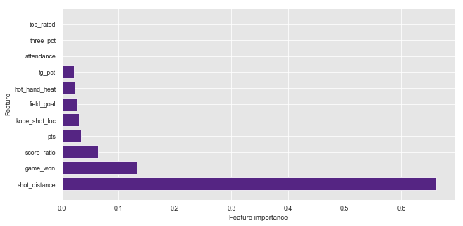

```python
from sklearn.ensemble import RandomForestClassifier

#random forest classifier with n_estimators=10 (default)
clf_rf = RandomForestClassifier(random_state=43)
clr_rf = clf_rf.fit(X_train,y_train)

print("Accuracy on training set: {:.3f}".format(accuracy_score(y_train,clf_rf.predict(X_train))))
print("Accuracy on test set: {:.3f}".format(accuracy_score(y_test,clf_rf.predict(X_test))))
plot_feature_importances_playoffs(clr_rf)
```

### Evaluation

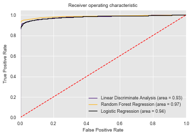

```python
from sklearn.metrics import roc_auc_score
from sklearn.metrics import roc_curve

lda_roc_auc = roc_auc_score(y_test, lda.predict(X_test))
lda_fpr, lda_tpr, lda_thresholds = roc_curve(y_test, lda.predict_proba(X_test)[:,1])

rf_roc_auc = roc_auc_score(y_test, clf_rf.predict(X_test))
rf_fpr, rf_tpr, rf_thresholds = roc_curve(y_test, clf_rf.predict_proba(X_test)[:,1])

logt_roc_auc = roc_auc_score(y_test, logreg.predict(X_test))
logt_fpr, logt_tpr, logt_thresholds = roc_curve(y_test, logreg.predict_proba(X_test)[:,1])

plt.figure()
plt.plot(lda_fpr, lda_tpr, label='Linear Discriminate Analysis (area = %0.2f)' % lda_roc_auc)
plt.plot(rf_fpr, rf_tpr, label='Random Forest Regression (area = %0.2f)' % rf_roc_auc)
plt.plot(logt_fpr, logt_tpr, label='Logistic Regression (area = %0.2f)' % logt_roc_auc)
plt.plot([0, 1], [0, 1],'r--')
plt.xlim([0.0, 1.0])
plt.ylim([0.0, 1.05])
plt.xlabel('False Positive Rate')
plt.ylabel('True Positive Rate')
plt.title('Receiver operating characteristic')
plt.legend(loc="lower right")
#plt.savefig('ROC')
plt.show()
```

## Kobe - Lord of the Rings

[figure not shown]

# Objective 2 - Shot Distance Probability and Association

Recall Objective 2:

1. Build models to provide arguments and evidence for or against the propositions below. For Each Quanitfy your findings with statistical evidence *(Test, CI, plots, etc.)*
   - 2.1. The odds of Kobe making a shot decreases with respect to the distance he is from the hoop.
   - 2.2. The probability of Kobe making a shot decreases linearly with respects to the distacne he is from the hoop.
   - 2.3. The relationship between the distance Kobe is from te basket and the odds of him making the shot is different if they are in the playoffs.

To perform this analysis we will need to analyze the dataset from the `shot_zone_range`. Which include the following categories and distribution over shots made and missed.

```
['8-16 ft.' 'Less Than 8 ft.' '24+ ft.' '16-24 ft.' 'Back Court Shot']
```

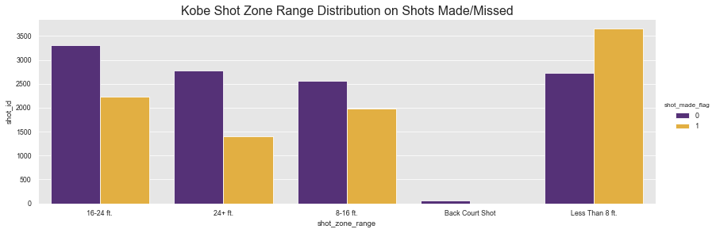

```python
print(kobe.shot_zone_range.unique())
sns.catplot(x='shot_zone_range', y='shot_id',
            hue='shot_made_flag', kind='bar', height=4, aspect=11.7/4,
           data=kobe.groupby(['shot_zone_range','shot_made_flag'])['shot_id'].count().reset_index())
plt.title("Kobe Shot Zone Range Distribution on Shots Made/Missed", fontsize=16)
```

```python
shotrange = pd.crosstab(train.shot_made_flag,
                                        train.shot_zone_range).sort_values('shot_made_flag', ascending=False) #[['16-24 ft.','8-16 ft.','Less Than 8 ft.']]
shot_range = sm.stats.Table(shotrange)
shot_range.table_orig
```

| shot_zone_range shot_made_flag | 16-24 ft. | 24+ ft. | 8-16 ft. | Back Court Shot | Less Than 8 ft. |
| --- | --- | --- | --- | --- | --- |
| 1 | 2236 | 1394 | 1983 | 0 | 3653 |
| 0 | 3305 | 2780 | 2555 | 60 | 2731 |

```python
kobe.shot_distance.head()
```

```
0    15
1     0
2    14
3     0
4    12
Name: shot_distance, dtype: int64
```

```python
part2 = kobe[['shot_distance', 'shot_made_flag']].corr()
part2['shot_made_flag'].sort_values(ascending=False)
```

```
shot_made_flag    1.000
shot_distance    -0.196
Name: shot_made_flag, dtype: float64
```

Below is a `SAS` output of hte *Cochran-Mantel-Haenszel* table output for our review the linear relationship between `shot_distance` and `shot_made`. We can see the $\chi^2 = 713.0227$ for the row mean score difference, and simisimilarly to the *General Association* score. Moreover the *nonzero Correlation* value is nearly 500. All test provided significant evidence this correlation test is highly significant

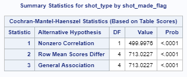

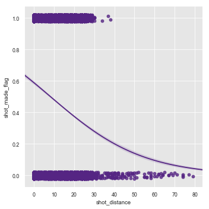

```python
# shot probability as a function of shot distance
sns.lmplot(x="shot_distance", y="shot_made_flag", data = kobe,  y_jitter=.02, logistic=True)
```

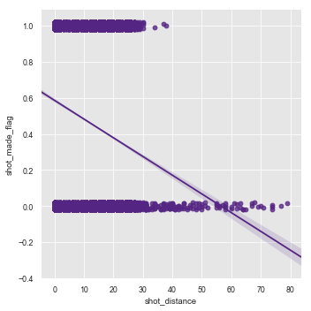

```python
# shot probability as a function of shot distance
sns.lmplot(x="shot_distance", y="shot_made_flag", data = kobe,  y_jitter=.02, logistic=False)
```

#### Chi-squared Independence Test

To start off, we will perfomr a $\chi^2$ independence test to determine whether Kobe's shots are independent of the shot range to gain a better understanding of the overall relationship between the two varaiables.

To perform this calculation, we will perform two types of Independence test: (1) Pearson Chi-Squared test and (2) Likilhood Ratio Test.

Test 1 is the test using **Perasrons's Chi-squared Statistic**, which is defined as:

$X^2=\sum\limits_{i=1}^I \sum\limits_{j=1}^J \dfrac{(O_{ij}-E_{ij})^2}{E_{ij}}$

```python
chi2, p, dof, ex = stats.chi2_contingency(shot_range.table)

print("Pearson's Chi-squared test with Yates' continuity correction")
print("X-squared: ", chi2)
print("p-value  : ", p)
print("degree of f: ", dof)
```

```
Pearson's Chi-squared test with Yates' continuity correction
X-squared:  711.9279234120621
p-value  :  9.108357067361717e-153
degree of f:  4
```

**Likelihood Ratio Chi-Square Test**

Test 2 is the test **Likelihood Ratio Chi-Squared Statistic**, which is defined as:

$G^2=2\sum\limits_{i=1}^I \sum\limits_{j=1}^J O_{ij}\text{log}\left(\dfrac{O_{ij}}{E_{ij}}\right)$

```python
chi2, p, dof, ex = stats.chi2_contingency(shot_range.table, lambda_="log-likelihood", correction=False)
print("Likelihood ratio test")
print("G2 - Likelihood-ratio stat: ", chi2)
print("p-value  : ", p)
print("degree of f: ", dof)
```

```
Likelihood ratio test
G2 - Likelihood-ratio stat:  734.2791820999303
p-value  :  1.3161762333403974e-157
degree of f:  4
```

**Interpretation** In review of the chi-square independence test we otained a $\chi^2 = 711.93$ and a likelihood squared statistic $G^2 = 734.28$, which both test provided a probability value of p-value < 0.001. Therefore, given the large $\chi^2$ statistics for the test of independence at a degree of freedom of 4, we conclude there is sufficient significant evidence to **reject the null hythoesis for independence indicating a relationship existing between Kobe's shots and shot range**.

#### Residuals Analysis based off the Independence Test

Since there is evidence of a relationship, we assess the residiuals to gain a beter understanding the degress and which variables are suggesting this lack of independence. We begin with calculating the Critical $\chi^2$ Value that uses the $\chi^2$ distribution table when providing the degrees of freedm and left side probability curve.

$X^2=\sum \dfrac{(n_{ij}-n\pi_{ij})^2}{n\pi_{ij}}$

```python
stats.chi2.isf(q=0.05, df=4)
```

```
9.487729036781158
```

```python
shot_range.chi2_contribs
```

| shot_zone_range shot_made_flag | 16-24 ft. | 24+ ft. | 8-16 ft. | Back Court Shot | Less Than 8 ft. |
| --- | --- | --- | --- | --- | --- |
| 1 | 24.135 | 120.550 | 1.165 | 26.319 | 221.021 |
| 0 | 19.565 | 97.723 | 0.944 | 21.336 | 179.169 |

**Interpretation:** Reviewing the above Standardized Pearson residuals based on the $\chi^2$ distribution found the following `shot_zone_range`'s to have overwhellming evidence of statistical significance as the residuals are greater than the Critical $\chi^2 = 9.49$, `16-24 ft.`, `24+ft.`, `Back Court Shot`, `Less Than 8ft.`. Moreover, it appears that `24+ft` and `less Than 8ft` resulted in the highest residuals indicate these are key variables suggesting Kobe's `shote_made` and `shot_zone_range` are associated.

### Odds Ratio and Difference in proportions

Now that we have rejected the null hypothesis for independence, the next step is to measure the magnitude of the relationshiop between `shot_made_flag` and `shot_zone_range`. To do this we will utilize two different measures of associations:

1. **differnece in proportions**
2. **odds ratio**

**Partitioning and Odds Ratio**

Next we evaluate the **Odds Ratio** which provides ratio statistics on the probability of sccess for a given conditional probaility. For each of the `shot_zone_range_` that was indicated to be related, we will evaluate the `Odds` = $\theta$ of making the shot from a given range. To focus on the categorical variables into individual Odds Ratio test, we can determine the specific distance that are no related and are important for the overall finding for evaluating the probability if Kobe's shot decreases with respects to the distance.

$\pi = \dfrac{odds}{(odds+1)}$

$odds_1=\dfrac{P(Z=1|Y=1)}{P(Z=2|Y=1)}=\dfrac{\pi_{1|1}}{\pi_{2|1}}=\dfrac{\pi_{1|1}}{1-\pi_{1|1}}$

`16-24ft vs 24+ft.` - $\hat{\theta}_{12}=\dfrac{2236\times 2780}{1394\times 3305}=1.349$

```python
print("Effect prob 16-24 ft. vs 24+ ft.: ",round((shotrange['16-24 ft.'][1]*shotrange['24+ ft.'][0]) /
                                           (shotrange['24+ ft.'][1]*shotrange['16-24 ft.'][0]),3))

print("Effect prob 16-24 ft. vs Less Than 8 ft.: ",round((shotrange['16-24 ft.'][1]*shotrange['Less Than 8 ft.'][0]) /
                                           (shotrange['Less Than 8 ft.'][1]*shotrange['16-24 ft.'][0]),3))

print("Effect prob Less Than 8 ft. vs 16-24 ft.: ",round((shotrange['16-24 ft.'][0]*shotrange['Less Than 8 ft.'][1]) /
                                           (shotrange['Less Than 8 ft.'][0]*shotrange['16-24 ft.'][1]),3))

#print("Effect prob 16-24 ft. vs Back Court Shot: ",round((shotrange['16-24 ft.'][0]*shotrange['Back Court Shot'][1]) /                                            (shotrange['Back Court Shot'][0]*shotrange['16-24 ft.'][1]),3))

#print("Effect prob 24+ ft. vs Back Court Shot: ",round((shotrange['24+ ft.'][0]*shotrange['Back Court Shot'][1]) /                                            (shotrange['Back Court Shot'][0]*shotrange['24+ ft.'][1]),3))

print("Effect prob 24+ ft. vs Less Than 8 ft.: ",round((shotrange['24+ ft.'][1]*shotrange['Less Than 8 ft.'][0]) /
                                           (shotrange['Less Than 8 ft.'][1]*shotrange['24+ ft.'][0]),3))


print("Effect prob Less Than 8 ft. vs 24+ ft. : ",round((shotrange['24+ ft.'][0]*shotrange['Less Than 8 ft.'][1]) /
                                           (shotrange['Less Than 8 ft.'][0]*shotrange['24+ ft.'][1]),3))

#print("Effect prob Back Court Shot vs Less Than 8 ft.: ",round((shotrange['Back Court Shot'][1]*shotrange['Less Than 8 ft.'][0]) /                                                               (shotrange['Less Than 8 ft.'][1]*shotrange['Back Court Shot'][0]),3))
```

```
Effect prob 16-24 ft. vs 24+ ft.:  1.349
Effect prob 16-24 ft. vs Less Than 8 ft.:  0.506
Effect prob Less Than 8 ft. vs 16-24 ft.:  1.977
Effect prob 24+ ft. vs Less Than 8 ft.:  0.375
Effect prob Less Than 8 ft. vs 24+ ft. :  2.668
```

**Interpretation - Odds Ratio:** Above are the odds ratio estimates for the variables that were identified as related. We can conclude the following about Kobe's shots, based on the odds scale:

**Therefore we can conclude, Yes, Kobe's shot decreases the further out the shot is taken. More specifically, the shorter the shots are the more likely Kobe would make the shots.**, in which we found:

- Shots `Less than 8ft` are estimated to be **almost 2 times likely (98%) a make** than shots taken at `16-24ft.`
- Shots `Less than 8ft` are estimate to be **over 2.5 time likely to make** than shots takens at `24+ft.`

**Linear Association**

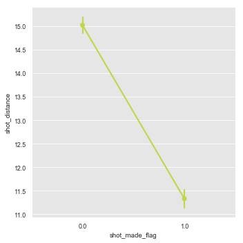

```python
sns.catplot(x="shot_made_flag", y="shot_distance", kind="point", data=kobe);
```

```python
shot_range.table_orig
```

| shot_zone_range shot_made_flag | 16-24 ft. | 24+ ft. | 8-16 ft. | Back Court Shot | Less Than 8 ft. |
| --- | --- | --- | --- | --- | --- |
| 1 | 2236 | 1394 | 1983 | 0 | 3653 |
| 0 | 3305 | 2780 | 2555 | 60 | 2731 |

```python
short_v_midrange = sm.stats.Table2x2(shot_range.table_orig[['Less Than 8 ft.','8-16 ft.']].values)
short_v_farrange = sm.stats.Table2x2(shot_range.table_orig[['Less Than 8 ft.','16-24 ft.']].values)
short_v_deeeprange = sm.stats.Table2x2(shot_range.table_orig[['Less Than 8 ft.','24+ ft.']].values)

print("Less than 8tf. vs Midrange (8-16ft)")
print("Odds Ratio: ", short_v_midrange.oddsratio)
print("Confidence INterval: ", short_v_midrange.oddsratio_confint())

print("\nLess than 8tf. vs Far Range (16-24tf)")
print("Odds Ratio: ", short_v_farrange.oddsratio)
print("Confidence INterval: ", short_v_farrange.oddsratio_confint())

print("\nLess than 8tf. vs Deep Range (24+)")
print("Odds Ratio: ", short_v_deeeprange.oddsratio)
print("Confidence INterval: ", short_v_deeeprange.oddsratio_confint())
```

```
Less than 8tf. vs Midrange (8-16ft)
Odds Ratio:  1.7234399757883423
Confidence INterval:  (1.5960278559327132, 1.8610235022555515)

Less than 8tf. vs Far Range (16-24tf)
Odds Ratio:  1.9770954501715872
Confidence INterval:  (1.837789725950275, 2.126960644024703)

Less than 8tf. vs Deep Range (24+)
Odds Ratio:  2.6675341882115484
Confidence INterval:  (2.459456548275177, 2.8932158408196766)
```

**Interpretation - Odds Ratio:** Above are the odds ratio estimates for the variables that were identified as related. We can conclude the following about Kobe's shots, based on the odds scale:

**Therefore we can conclude, Yes, Kobe's shot decreases the further out the shot is taken. More specifically, the shorter the shots are the more likely Kobe would make the shots.**, Furthermore, each of the confidence intervals above did not contain 1, therefore, additional evidence is provided kobe's shot and shot distance are related.

## 2.3 Kobe Shot Range vs Playoffs

> Objective: The relationship between the distance Kobe is from te basket and the odds of him making the shot is different if they are in the playoffs.

To do this we will create a three way contingency table with the three categorical variables of `playoffs`, `shot_made_flag`, and `shot_zone_range`.

```python
shots_playoffs = pd.crosstab([train[train.playoffs==1].shot_zone_range], train.shot_made_flag).T
shots_seaon = pd.crosstab([train[train.playoffs==0].shot_zone_range], train.shot_made_flag).T
```

```python
kobe.head()
```

|  | action_type | arena_temp | attendance | avgnoisedb | combined_shot_type | game_date | game_event_id | game_id | lat | loc_x | loc_y | lon | matchup | minutes_remaining | opponent | period | playoffs | recId | season | seconds_remaining | shot_distance | shot_id | shot_made_flag | shot_type | shot_zone_area | shot_zone_basic | shot_zone_range | team_id | team_name | … |
| --- | --- | --- | --- | --- | --- | --- | --- | --- | --- | --- | --- | --- | --- | --- | --- | --- | --- | --- | --- | --- | --- | --- | --- | --- | --- | --- | --- | --- | --- | --- |
| 0 | Jump Shot | 69 | 14707 | 94.060 | Jump Shot | 36830 | 12 | 20000012 | 34.044 | -157 | 0 | -118.427 | LAL @ POR | 10 | POR | 1 | 0 | 1 | 2000-01 | 22 | 15 | 2 | 0.000 | 2PT Field Goal | Left Side(L) | Mid-Range | 8-16 ft. | 1610612747 | Los Angeles Lakers | … |
| 1 | Jump Shot | 69 | 14707 | 94.060 | Jump Shot | 36830 | 35 | 20000012 | 33.909 | -101 | 135 | -118.371 | LAL @ POR | 7 | POR | 1 | 0 | 2 | 2000-01 | 45 | 16 | 3 | nan | 2PT Field Goal | Left Side Center(LC) | Mid-Range | 16-24 ft. | 1610612747 | Los Angeles Lakers | … |
| 2 | Jump Shot | 69 | 14707 | 94.060 | Jump Shot | 36830 | 43 | 20000012 | 33.869 | 138 | 175 | -118.132 | LAL @ POR | 6 | POR | 1 | 0 | 3 | 2000-01 | 52 | 22 | 4 | nan | 2PT Field Goal | Right Side Center(RC) | Mid-Range | 16-24 ft. | 1610612747 | Los Angeles Lakers | … |
| 3 | Driving Dunk Shot | 69 | 14707 | 94.060 | Dunk | 36830 | 155 | 20000012 | 34.044 | 0 | 0 | -118.270 | LAL @ POR | 6 | POR | 2 | 0 | 4 | 2000-01 | 19 | 0 | 5 | 1.000 | 2PT Field Goal | Center(C) | Restricted Area | Less Than 8 ft. | 1610612747 | Los Angeles Lakers | … |
| 4 | Jump Shot | 69 | 14707 | 94.060 | Jump Shot | 36830 | 244 | 20000012 | 34.055 | -145 | -11 | -118.415 | LAL @ POR | 9 | POR | 3 | 0 | 5 | 2000-01 | 32 | 14 | 6 | 0.000 | 2PT Field Goal | Left Side(L) | Mid-Range | 8-16 ft. | 1610612747 | Los Angeles Lakers | … |

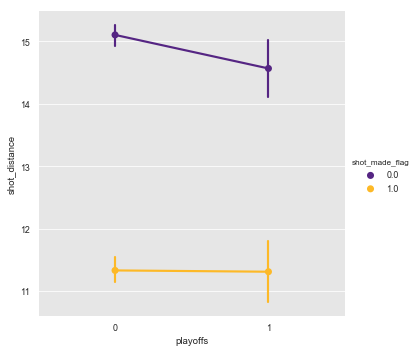

```python
#g = sns.FacetGrid(kobe, hue="shot_made_flag", col="playoffs", height=4)
#g.mag(catplot, x="sex", y="survived", hue="class", kind="point", data=titanic)

sns.catplot(x="playoffs", y="shot_distance", hue="shot_made_flag",
            kind="point", data=kobe);

#g.add_legend();
```

**Linear Association**

```python
short_v_midrange = sm.stats.Table2x2(shots_playoffs[['Less Than 8 ft.','8-16 ft.']].values)
short_v_farrange = sm.stats.Table2x2(shots_playoffs[['Less Than 8 ft.','16-24 ft.']].values)
short_v_deeeprange = sm.stats.Table2x2(shots_playoffs[['Less Than 8 ft.','24+ ft.']].values)


print("Playoffs:\n")
print("Less than 8tf. vs Midrange (8-16ft)")
print("Odds Ratio: ", short_v_midrange.oddsratio)
print("Confidence INterval: ", short_v_midrange.oddsratio_confint())

print("\nLess than 8tf. vs Far Range (16-24tf)")
print("Odds Ratio: ", short_v_farrange.oddsratio)
print("Confidence INterval: ", short_v_farrange.oddsratio_confint())

print("\nLess than 8tf. vs Deep Range (24+)")
print("Odds Ratio: ", short_v_deeeprange.oddsratio)
print("Confidence INterval: ", short_v_deeeprange.oddsratio_confint())
```

```
Playoffs:

Less than 8tf. vs Midrange (8-16ft)
Odds Ratio:  0.6635169053595157
Confidence INterval:  (0.546387295208074, 0.8057557113040342)

Less than 8tf. vs Far Range (16-24tf)
Odds Ratio:  0.5424273534794447
Confidence INterval:  (0.44772234612715156, 0.6571649513315895)

Less than 8tf. vs Deep Range (24+)
Odds Ratio:  0.4426093186964912
Confidence INterval:  (0.3568446744788252, 0.5489867805455978)
```

```python
short_v_midrange = sm.stats.Table2x2(shots_seaon[['Less Than 8 ft.','8-16 ft.']].values)
short_v_farrange = sm.stats.Table2x2(shots_seaon[['Less Than 8 ft.','16-24 ft.']].values)
short_v_deeeprange = sm.stats.Table2x2(shots_seaon[['Less Than 8 ft.','24+ ft.']].values)


print("SEASON:\n")
print("Less than 8tf. vs Midrange (8-16ft)")
print("Odds Ratio: ", short_v_midrange.oddsratio)
print("Confidence INterval: ", short_v_midrange.oddsratio_confint())

print("\nLess than 8tf. vs Far Range (16-24tf)")
print("Odds Ratio: ", short_v_farrange.oddsratio)
print("Confidence INterval: ", short_v_farrange.oddsratio_confint())

print("\nLess than 8tf. vs Deep Range (24+)")
print("Odds Ratio: ", short_v_deeeprange.oddsratio)
print("Confidence INterval: ", short_v_deeeprange.oddsratio_confint())
```

```
SEASON:

Less than 8tf. vs Midrange (8-16ft)
Odds Ratio:  0.5664061943625461
Confidence INterval:  (0.5209601221371165, 0.6158167648152981)

Less than 8tf. vs Far Range (16-24tf)
Odds Ratio:  0.49929017757285826
Confidence INterval:  (0.46134419159441276, 0.5403572559550024)

Less than 8tf. vs Deep Range (24+)
Odds Ratio:  0.364419076320844
Confidence INterval:  (0.3338142408893802, 0.3978298314437242)
```

**Simsons Paradonx**

```python
tb = pd.crosstab(train.playoffs, train.shot_made_flag).T.sort_values('shot_made_flag', ascending=False).T.sort_values('playoffs', ascending=False)
print(tb)
tab = sm.stats.Table2x2(tb.values)
chi2, p, dof, ex = stats.chi2_contingency(tb, correction=False)

print("Pearson's Chi-squared test with Yates' continuity correction")
print("X-squared: ", round(chi2, 3))
print("p-value  : ", round(p, 3))
print("degree of f: ", dof)

hi, low = tab.oddsratio_confint()
print("odds ratio", tab.oddsratio)
print("Odds Ratio CI: ", (round(hi, 3), round(low, 3)))
print("\n2x2 Summary:")
print(tab.summary())
```

```
shot_made_flag     1     0
playoffs
1               1345  1689
0               7921  9742
Pearson's Chi-squared test with Yates' continuity correction
X-squared:  0.277
p-value  :  0.599
degree of f:  1
odds ratio 0.9794014591545628
Odds Ratio CI:  (0.906, 1.058)

2x2 Summary:
               Estimate   SE   LCB    UCB  p-value
--------------------------------------------------
Odds ratio        0.979        0.906 1.058   0.599
Log odds ratio   -0.021 0.040 -0.098 0.057   0.599
Risk ratio        0.989        0.947 1.032   0.600
Log risk ratio   -0.012 0.022 -0.055 0.032   0.600
--------------------------------------------------
```

```python
(189*10933) / (104*10845)
```

```
1.8320539419087136
```

[figure not shown]

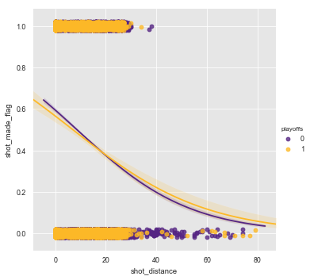

```python
# shot probability as a function of shot distance and playoffs
ax = plt.gca()
sns.lmplot(x="shot_distance", y="shot_made_flag", data = kobe, hue="playoffs", y_jitter=.02, logistic=True)
ax.set_title("Kobe's Shot Probability as a function of distance and playoffs")
```

Below are results from SAS to describe the `playoff` and `shot_made` associations.

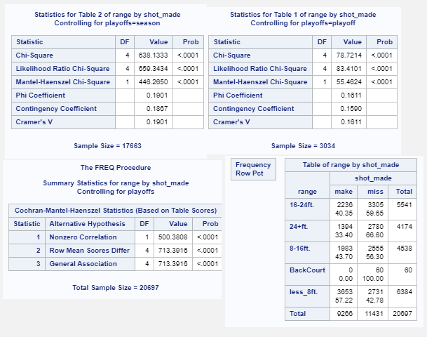

After reviewing the associations between kobe's shot performance during the `season` (top left plot) and `playoffs` (top right plot), the association are bot significant, but the season appears more significant, this is perhaps due to the umbalance in observations in the `playoffs`. This is also indicated by the Mantel-Haenszel table on the bottom left that used to assess the overall association while contrilling for playoffs.

**_this may still be a conclusion for part 1... need to add comment about playoffs**. Overall, when assess Kobe's shot, with the frequency table on the bottom right, this indicates given shots at less distance from the basket, such as <8 ft, 57% were made baskets, while among shots at further distances shuch as 16-24ft. indicate around 60% that are misses. and with the assessment discribed above, all test provides significant evidence that the shot distance is associate between shot being made/missed and the distance.

#### Homogeneity of Association

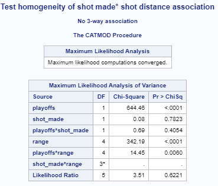

http://www.datavis.ca/courses/grcat/grc2.html

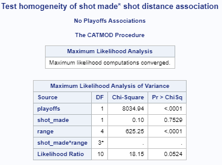

Above for the **Test of Homogeneity of associations**, `shot_made` when associated with `playoffs` and `range` are both not significant, indicating no homogenneity association, additionally, the likelihood ration for the `no-playoff` associations is borderline significant, and could be a canadiate for a reasonable model indicating a respectible fit.

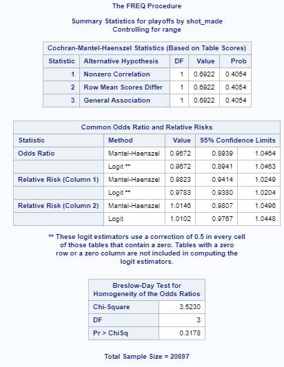

```
proc freq;
 weight count;
 tables range*playoffs*shot_made /chisq cmh nocol nopct;
run;
```

above is hte **beslow-day** test which provided a $\chi^2 = 3.5$ and a p-value=0.318 indicating a lack of evidence to reject our assumptiuon for homogeneous association. Based on the **Common Odds Ration and Relative Risk table**, there is indication to support our conclusion with 95% confidence the esitmate common ods ratio is 0.97 which could be between 0.89 and 1.04